# Predicting PM10 concentration in Le Havre, France

# Describing the data set

Loading the data set:

```r
library(VSURF)
A = VSURF::rep
str(A)
```

```
'data.frame':   1096 obs. of  18 variables:
 $ PM10     : int  13 22 29 25 23 17 20 17 32 31 ...
 $ NO       : int  15 25 31 36 72 53 31 28 47 44 ...
 $ NO2      : int  25 32 42 36 56 54 45 41 47 50 ...
 $ SO2      : int  5 3 10 4 15 NA 14 13 3 10 ...
 $ T.min    : num  0.6 -0.6 -2 1.9 5.7 NA 6.3 7.4 7 7.3 ...
 $ T.max    : num  8.4 7.6 1.2 6.5 8 NA 8.6 10.9 9.8 10.8 ...
 $ T.moy    : num  5.025 3.333 -0.583 4.675 7.238 ...
 $ DV.maxvv : int  210 330 190 270 220 NA 190 190 250 220 ...
 $ DV.dom   : num  338 45 180 225 NA ...
 $ VV.max   : int  16 8 6 7 9 NA 11 22 14 8 ...
 $ VV.moy   : num  9.17 4.43 3.42 3.92 6.08 ...
 $ PL.som   : int  19 5 0 0 0 0 0 4 1 0 ...
 $ HR.min   : int  79 81 74 86 94 NA 76 75 85 89 ...
 $ HR.max   : int  99 93 90 99 97 NA 92 95 95 97 ...
 $ HR.moy   : num  90.3 85.7 83 96.4 95.2 ...
 $ PA.moy   : num  1010 1018 1024 1022 1021 ...
 $ GTrouen  : num  0.7 -0.5 2.4 2.7 2.4 0.6 -0.1 0 -0.1 1.2 ...
 $ GTlehavre: num  -0.3 0 0.1 -0.2 -0.2 -0.3 -0.5 NA -0.5 0.1 ...
```

According to the data set description, PM10 concentrations were measured in Le Havre, France, by Air Normand, with the associated weather data provided by Meteo France, from 2004 to 2006. The monitoring station is situated in an urban site, close to traffic, and considered the most polluted in the region. We have **1096 observations.**

The data set description gives the following definitions for the **18 numeric variables** in the data set:

- PM10: Daily mean concentration of $\text{PM10}$, in $\mu g/m^3$.
- NO, NO2, SO2: Daily mean concentration of $\text{NO}$, $\text{NO}_2$ , $\text{SO}_2$ in $\mu g/m^3$.
- T.min, T.max, T.moy: Daily minimum, maximum and mean temperature, in degree Celsius.
- DV.maxvv, DV.dom: Daily maximum speed and dominant wind direction in degree.
- VV.max, VV.moy: Daily maximum and mean wind speed, in m/s.
- PL.som: Daily rainfall in mm.
- HR.min, HR.max, HR.moy: Daily minimum, maximum and mean relative humidity, in %.
- PA.moy: Daily mean air pressure in hPa.
- GTrouen, GTlehavre: Daily temperature gradient in degree Celsius in the cities of Rouen and Le Havre, respectively.

**PM10 is the target variable** we want to predict using the other 17 variables.

We have missing data:

```r
sum(is.na(A))
```

```
[1] 269
```

There is data missing in most columns:

```r
colnames(A)[ apply(A, 2, anyNA)]
```

```
 [1] "PM10"      "NO"        "NO2"       "SO2"       "T.min"     "T.max"     "T.moy"
 [8] "DV.maxvv"  "DV.dom"    "VV.max"    "VV.moy"    "HR.min"    "HR.max"    "HR.moy"
[15] "PA.moy"    "GTlehavre"
```

I will substitute the missing values for the mean of each variable:

```r
#Calculating the mean for each variable
mean_columns <- apply(A[,colnames(A)],2, mean, na.rm =  TRUE)

#Substituing the missing values by the mean
for (c in names(A)){
  A[,c] = ifelse(is.na(A[,c]), mean_columns[c], A[,c])
}

#Checking that there are no missing values
sum(is.na(A))
```

```
[1] 0
```

# Methodology

We are interested in Regression. For variable selection, I will use Random Forests with the VSURF package. Linear, Decision Tree and Random Forest models will be constructed to make predictions. They will be compared by calculating the Root Mean Squared Error (RSME) and the Mean Absolute Error (MAE). The data set into Learning and Test sets before modelling.

# Splitting the data set

The models will be trained using the Learning set. Around 20% of the data will be kept separately on the Test set to test the models’ predictions.

```r
splitProb <- c(0.8,0.2)
splitNames <-c("Learning","Test")

n = nrow(x=A)

splitVector<- sample( x=splitNames, size=n, prob=splitProb, replace=TRUE )

table(splitVector)/n
```

```
splitVector
 Learning      Test
0.7883212 0.2116788
```

```r
#getting the indeces
indeces<-list(
  learning = which(x=(splitVector=="Learning")),
  test=which(x=(splitVector=="Test"))
  )
#splitting the data set
learningSet<-A[indeces$learning,]
testSet<-A[indeces$test,]
```

# Linear Model

Linear model using all explanatory variables:

```r
L = lm(PM10~., data = learningSet)
summary(L)
```

```
Call:
lm(formula = PM10 ~ ., data = learningSet)

Residuals:
    Min      1Q  Median      3Q     Max
-17.233  -4.200  -0.700   3.088  33.620

Coefficients:
              Estimate Std. Error t value Pr(>|t|)
(Intercept) -75.099465  31.331422  -2.397 0.016749 *
NO            0.110504   0.013282   8.320 3.50e-16 ***
NO2           0.208806   0.021954   9.511  < 2e-16 ***
SO2           0.164353   0.020941   7.848 1.27e-14 ***
T.min        -0.041354   0.316300  -0.131 0.896009
T.max         0.837540   0.348803   2.401 0.016557 *
T.moy        -0.541528   0.595515  -0.909 0.363428
DV.maxvv     -0.004530   0.002662  -1.702 0.089134 .
DV.dom       -0.003416   0.002582  -1.323 0.186189
VV.max       -0.165668   0.136204  -1.216 0.224201
VV.moy        0.309176   0.188240   1.642 0.100868
PL.som       -0.253078   0.052579  -4.813 1.76e-06 ***
HR.min        0.094120   0.056594   1.663 0.096667 .
HR.max       -0.012930   0.077585  -0.167 0.867682
HR.moy       -0.059064   0.102811  -0.574 0.565789
PA.moy        0.081950   0.029914   2.740 0.006283 **
GTrouen      -0.152514   0.185332  -0.823 0.410786
GTlehavre     1.036329   0.311846   3.323 0.000928 ***
---
Signif. codes:  0 ‘***’ 0.001 ‘**’ 0.01 ‘*’ 0.05 ‘.’ 0.1 ‘ ’ 1

Residual standard error: 6.346 on 846 degrees of freedom
Multiple R-squared:  0.5887,    Adjusted R-squared:  0.5804
F-statistic: 71.23 on 17 and 846 DF,  p-value: < 2.2e-16
```

To check the gaussian assumption of the noise, I will use a QQ-plot of the studentized residuals:

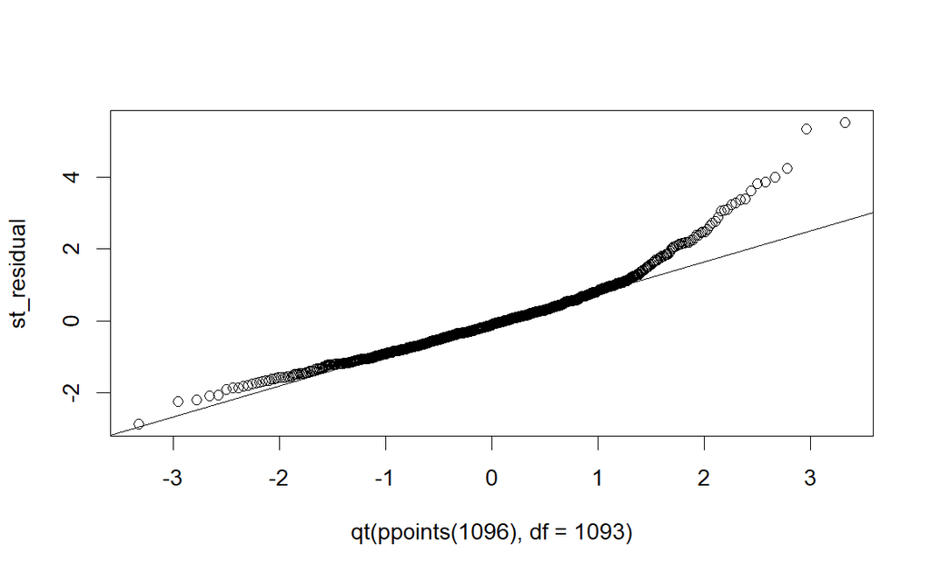

```r
#Studentized residuals - QQ plot
st_residual=rstudent(L)
#n=1096 #degrees of freedom n-3=1093
qqplot(qt(ppoints(1096), df=1093), st_residual)
qqline(st_residual, distribution=function(p){qt(p,df=1093)})
```

The QQ-plot is skewed and highly-tailed, so the noise does not appear to be Gaussian.

Using the Kolmogorov-Smirnov test to assess if the residuals have a student distribution.

```r
#Smirnov test
#n=1096 #degrees of freedom n-3=1093
#'pt' is for student distribution
ks.test(st_residual,'pt',1093)
```

```
    Asymptotic one-sample Kolmogorov-Smirnov test

data:  st_residual
D = 0.076597, p-value = 7.906e-05
alternative hypothesis: two-sided
```

The p-value is very small.

The noise does not seem to have a Gaussian distribution. This means that most parameters given in the linear model summary are not meaningful. We still can look at its $R^2$ score, use the linear model for prediction and calculate errors, but we can’t do much more.

# Variable Selection

Many of the explanatory variables are highly dependent on each other.

For example, the temperature variables:

```r
cor(learningSet[,c("T.min","T.max","T.moy")])
```

```
          T.min     T.max     T.moy
T.min 1.0000000 0.9301058 0.9764767
T.max 0.9301058 1.0000000 0.9831968
T.moy 0.9764767 0.9831968 1.0000000
```

Or humidity variables:

```r
cor(learningSet[,c("HR.min","HR.max","HR.moy")])
```

```
          HR.min    HR.max    HR.moy
HR.min 1.0000000 0.6012604 0.9107279
HR.max 0.6012604 1.0000000 0.8121977
HR.moy 0.9107279 0.8121977 1.0000000
```

And several others.

Since we cannot make the Gaussian assumption of the noise, we cannot use the p-values given by the linear model to perform variable selection. Instead, I will perform variable selection using Random Forest to detect the most relevant variables for prediction.

```r
library('VSURF')
#Three steps variable selection procedure based on random forests for
#supervised classification and regression problems.
#First step ("thresholding step") is dedicated to eliminate irrelevant
#variables from the dataset. Second step ("interpretation step")
#aims to select all variables related to the response for interpretation purpose.
#Third step ("prediction step") refines the selection by eliminating redundancy in
#the set of variables selected by the second step, for prediction purpose.
set.seed(221921186)
Vy<-VSURF(PM10~.,data=learningSet, nmj=1)
```

```
Thresholding step
Estimated computational time (on one core): 47.8 sec.

Interpretation step (on 17 variables)
Estimated computational time (on one core): between 13.6 sec. and  61.2 sec.

Prediction step (on 13 variables)
Maximum estimated computational time (on one core): 36.4 sec.
```

```r
summary(Vy)
```

```
 VSURF computation time: 1.8 mins

 VSURF selected:
    17 variables at thresholding step (in 50.8 secs)
    13 variables at interpretation step (in 37.9 secs)
    9 variables at prediction step (in 21.4 secs)
```

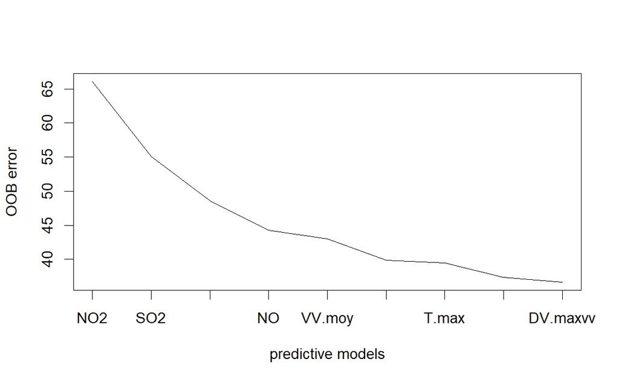

```r
plot(Vy,step="pred",var.names=TRUE)
```

The selected explanatory variables are:

```r
variables = c()
for (i in Vy$varselect.pred){
  variables <- c(variables,colnames(learningSet)[i+1])
}
variables
```

```
[1] "NO2"       "SO2"       "GTlehavre" "NO"        "VV.moy"    "T.moy"     "T.max"
[8] "PL.som"    "DV.maxvv"
```

Removing other explanatory variables from Learning and Test sets:

```r
learningSet= learningSet[,c(variables,"PM10")]
testSet= testSet[,c(variables,"PM10")]
```

# Back to the Linear Model

We can create a linear model using only the variables selected:

```r
L2 = lm(PM10~., data = learningSet)
summary(L2)
```

```
Call:
lm(formula = PM10 ~ ., data = learningSet)

Residuals:
    Min      1Q  Median      3Q     Max
-17.277  -4.300  -0.827   3.060  33.382

Coefficients:
             Estimate Std. Error t value Pr(>|t|)
(Intercept) 10.687781   1.345186   7.945 6.11e-15 ***
NO2          0.193515   0.021515   8.995  < 2e-16 ***
SO2          0.170944   0.020308   8.418  < 2e-16 ***
GTlehavre    1.028902   0.262108   3.925 9.35e-05 ***
NO           0.114678   0.012649   9.066  < 2e-16 ***
VV.moy      -0.016031   0.080439  -0.199   0.8421
T.moy       -0.135677   0.270228  -0.502   0.6157
T.max        0.374515   0.251545   1.489   0.1369
PL.som      -0.295779   0.048716  -6.071 1.91e-09 ***
DV.maxvv    -0.006535   0.002605  -2.509   0.0123 *
---
Signif. codes:  0 ‘***’ 0.001 ‘**’ 0.01 ‘*’ 0.05 ‘.’ 0.1 ‘ ’ 1

Residual standard error: 6.393 on 854 degrees of freedom
Multiple R-squared:  0.5786,    Adjusted R-squared:  0.5741
F-statistic: 130.3 on 9 and 854 DF,  p-value: < 2.2e-16
```

The $R^2$ didn’t change much, but the model is simpler. We still have the problem that the noise is not gaussian, but we can do some predictions. Using the linear model to predict the PM10 values in the Test Set:

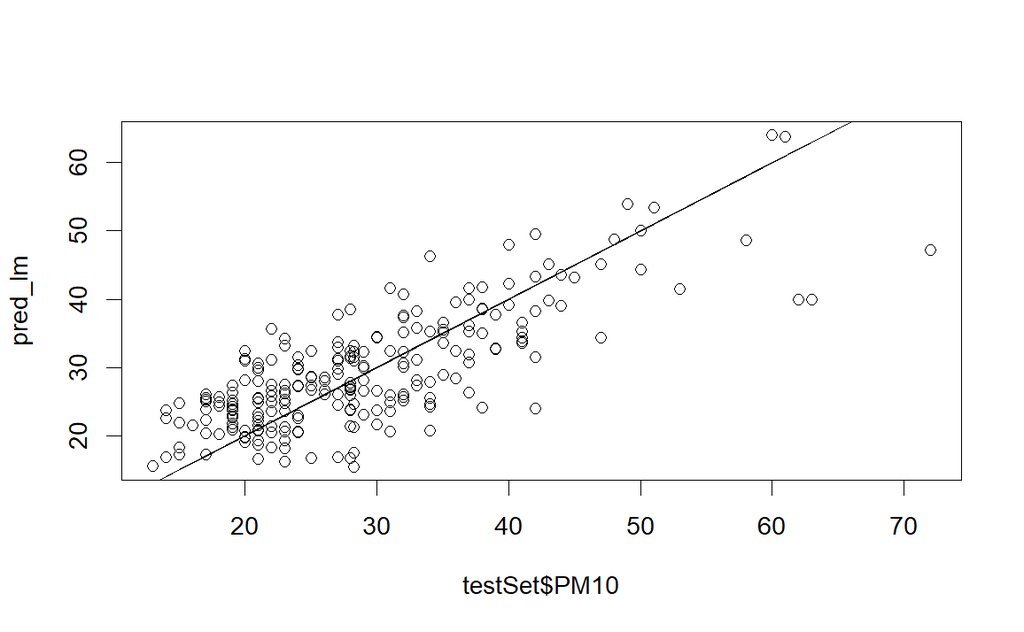

```r
#predictions for Linear Model
pred_lm <- predict(L2, newdata = testSet)
#true values vs predictions
plot(testSet$PM10,pred_lm)
lines(testSet$PM10,testSet$PM10)
```

The Root Mean Squared Error (RMSE) of the predictions is:

```r
RMSE_lm = sqrt(1 /nrow(testSet)*sum((testSet$PM10-pred_lm)**2))
RMSE_lm
```

```
[1] 6.394338
```

The Mean Absolute Error (MAE) of the predictions is:

```r
MAE_lm = 1 /nrow(testSet)*sum(abs(testSet$PM10-pred_lm))
MAE_lm
```

```
[1] 4.995213
```

# Decision Tree

Since the linear model might not be ideal in our case, we can try some non linear models.

I will construct a decision tree using the explanatory variables selected before.

First, I obtain the maximal tree, maintaining the complexity parameter CP low.

The minimum number of observations in a node in order that an split is attempted is set as 2.

```r
library(rpart)
library(rpart.plot)
#maximal tree
tree_max=rpart(PM10~.,data=learningSet, minsplit=2, cp = 10^(-9))
rpart.plot(tree_max)
```

[output not shown]

Then, I will prune this tree using the 1-SE rule.

```r
finalcart=function(T)
{
  P=printcp(T)
  CV=P[,4] #crossvalidation error
  a=which(CV==min(CV)) #finding the row with the smallest CV
  s=P[a,4]+P[a,5] #adding the standard deviation - the new threshold used in the 1SE rule
  ss=min(s) #in case s is a vector (several values are the min)
  b=which(CV<=ss)
  d=b[1] #selected value of cp
  Tf=prune(T,cp=P[d,1]) #pruning the maximal tree
  finalcart=Tf
}
tree = finalcart(tree_max)
```

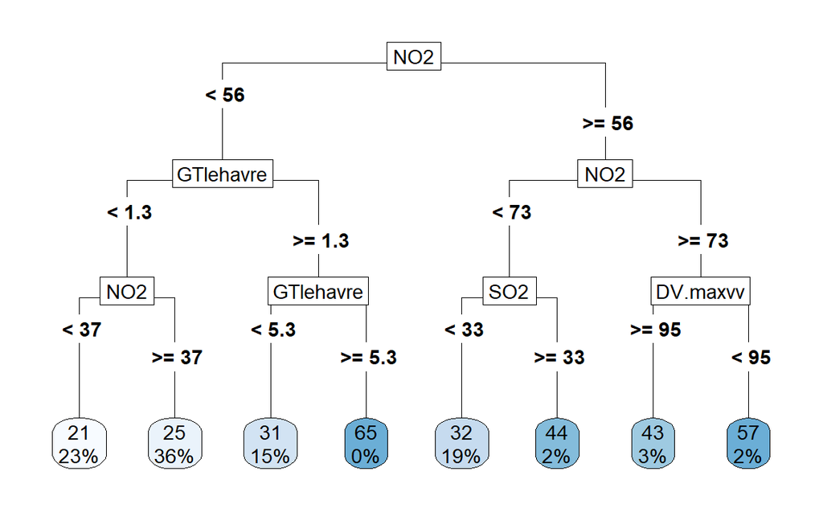

```r
rpart.plot(tree, type = 5)
```

Using the decision tree model to predict the PM10 values in the Test Set:

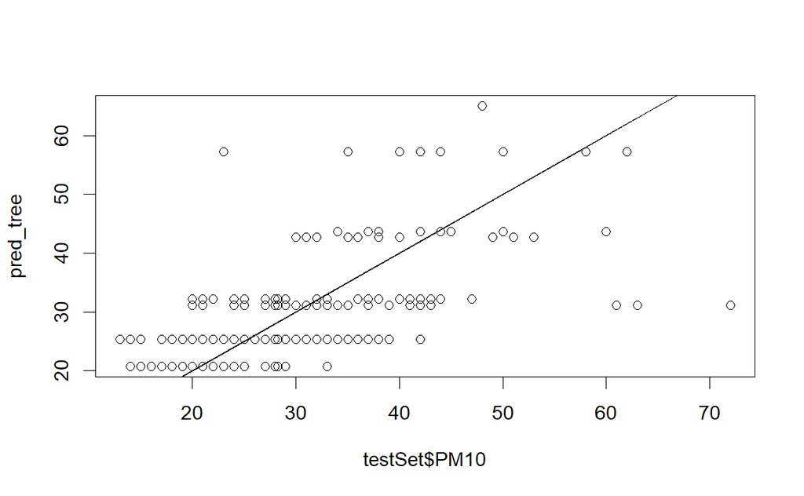

```r
pred_tree<- predict(tree, newdata = testSet)
plot(testSet$PM10,pred_tree)
lines(testSet$PM10,testSet$PM10)
```

The RMSE error for this model:

```r
RMSE_tree = sqrt(1 /nrow(testSet)*sum((testSet$PM10-pred_tree)**2))
RMSE_tree
```

```
[1] 8.123572
```

The MAE error for this model:

```r
MAE_tree = 1 /nrow(testSet)*sum(abs(testSet$PM10-pred_tree))
MAE_tree
```

```
[1] 5.993454
```

# Random Forest

Finally, we can also use a Random Forest model.

```r
library(randomForest)
RF=randomForest(PM10~.,data=learningSet)
```

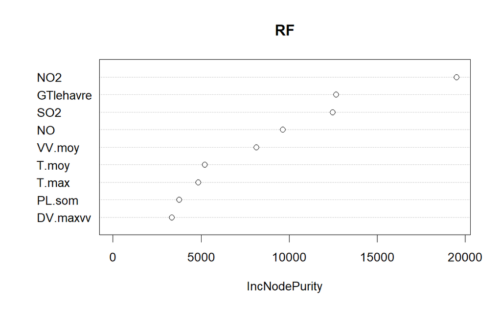

```r
varImpPlot(RF)
```

Using the random forest model to predict the PM10 values in the Test Set:

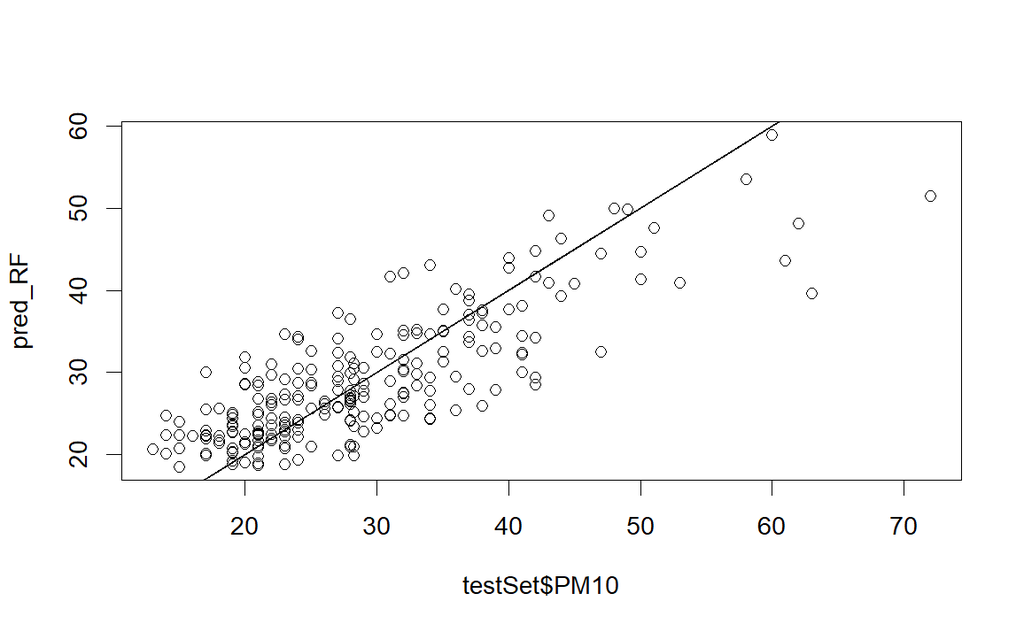

```r
pred_RF<- predict(RF, newdata = testSet)
plot(testSet$PM10,pred_RF)
lines(testSet$PM10,testSet$PM10)
```

The RMSE error for this model:

```r
RMSE_RF = sqrt(1 /nrow(testSet)*sum((testSet$PM10-pred_RF)**2))
RMSE_RF
```

```
[1] 5.867526
```

The MAE error for this model:

```r
MAE_RF = 1 /nrow(testSet)*sum(abs(testSet$PM10-pred_RF))
MAE_RF
```

```
[1] 4.486552
```

# Discussion and Conclusion

```r
results <- c(RMSE_lm, MAE_lm)
results <- rbind(results, c(RMSE_tree, MAE_tree))
results <- rbind(results,c(RMSE_RF, MAE_RF))
row.names(results) <- c("Linear Model", "Decision Tree", "Random Forest")
colnames(results) <- c("RMSE", "MAE")
results
```

```
                  RMSE      MAE
Linear Model  6.394338 4.995213
Decision Tree 8.123572 5.993454
Random Forest 5.867526 4.486552
```

The Random Forest model has predictions with the smallest RSME and MAE, followed by the Linear Model. The Decision Tree has the worst performance, but it does provide some nice explainability.

The concentration of other pollutants such as $\text{NO}$, $\text{NO}_2$ and $\text{SO}_2$ in the atmosphere is one of the main predictors of the concentration of $\text{PM10}$. It is also case of the temperature gradient in Le Havre, where this particular monitoring station is located. When this temperature gradient is high, there seems to be a higher concentration of $\text{PM10}$.